# R Notebook

To investigate further, compare this plot to BIC which is more parsimonious

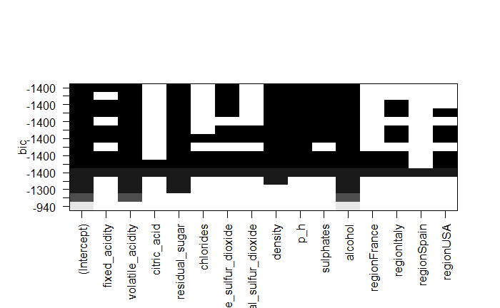

```r
plot(red_subsets_forward, scale = "bic")
```

The BIC plot shows the change in bic relative to the baseline (bic for intercept only model) and we can see that the lowest BIC score is seen with fixed_acidity, volatile_acidity, residual_sugar, free_sulphur_dioxide, density, pH, sulphates, and alcohol (i.e. 8 predictors)

We can plot R2 values of each model as a function of the number of predictors to investigate this relationship further

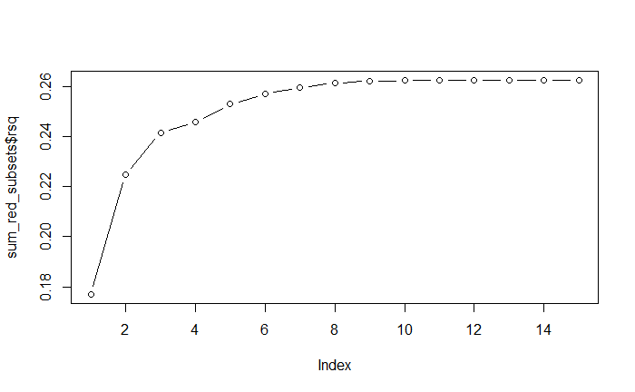

```r
plot(sum_red_subsets$rsq, type = "b")
```

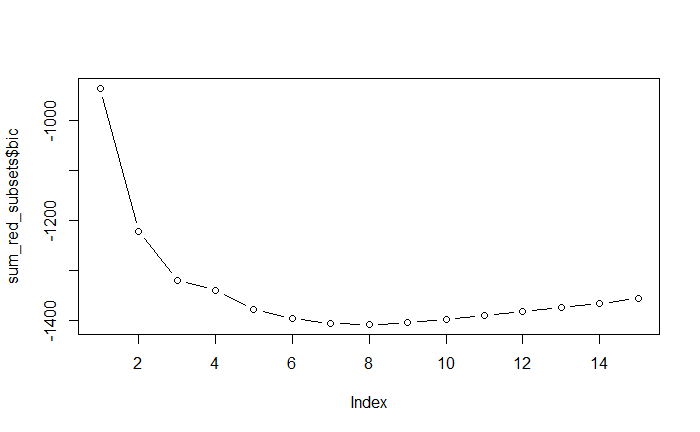

```r
plot(sum_red_subsets$bic, type = "b")
```

These graphs show there is some consistency that the number of predictors is 6-8. If we err on the more conservative number of predictors (in order to keep the model simple), this would result in a model for red wine quality:

quality = alcohol + volatile_acidity + residual_sugar + density + pH + sulphates

I will build this model and compare to the previous mod3_red

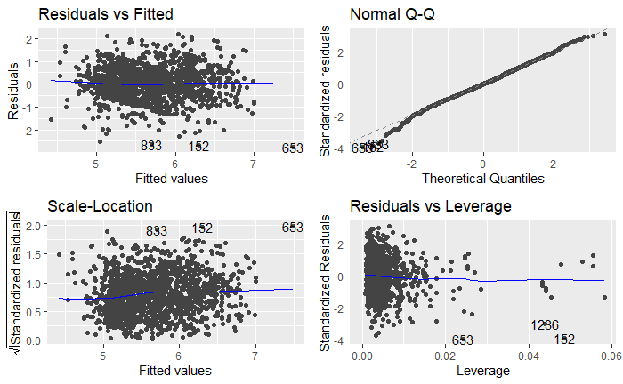

```r
mod_red_auto <- lm(quality ~ alcohol + volatile_acidity + residual_sugar + density + p_h + sulphates,
                   data = red_trim)

autoplot(mod_red_auto)
```

```r
summary(mod_red_auto)
```

```
Call:
lm(formula = quality ~ alcohol + volatile_acidity + residual_sugar +
    density + p_h + sulphates, data = red_trim)

Residuals:
     Min       1Q   Median       3Q      Max
-2.74077 -0.44642 -0.00983  0.48560  2.17556

Coefficients:
                  Estimate Std. Error t value Pr(>|t|)
(Intercept)       0.165249  12.905959   0.013   0.9898
alcohol           0.326076   0.020921  15.586  < 2e-16 ***
volatile_acidity -1.130482   0.108106 -10.457  < 2e-16 ***
residual_sugar   -0.005556   0.014100  -0.394   0.6936
density           3.293676  12.763050   0.258   0.7964
p_h              -0.290219   0.128387  -2.261   0.0239 *
sulphates         0.588947   0.112494   5.235 1.87e-07 ***
---
Signif. codes:  0 ‘***’ 0.001 ‘**’ 0.01 ‘*’ 0.05 ‘.’ 0.1 ‘ ’ 1

Residual standard error: 0.7108 on 1592 degrees of freedom
Multiple R-squared:  0.301, Adjusted R-squared:  0.2984
F-statistic: 114.3 on 6 and 1592 DF,  p-value: < 2.2e-16
```

Very interesting to see that although the automated model has additional elements to the manual one, those additional predictors are not statistically significant. It could be argued that although they correlate to the data, they do not have significant effect on the model. Although the R^2 is higher than we found in our mod3_red summary, this doesn’t take into account whether they are significant statistically for the model.

## Automated for white wines

```r
white_subsets <- regsubsets(quality ~ ., data =  white_trim, nvmax = 14, method = "forward")
white_subsets
```

```
Subset selection object
Call: regsubsets.formula(quality ~ ., data = white_trim, nvmax = 14,
    method = "forward")
15 Variables  (and intercept)
                     Forced in Forced out
fixed_acidity            FALSE      FALSE
volatile_acidity         FALSE      FALSE
citric_acid              FALSE      FALSE
residual_sugar           FALSE      FALSE
chlorides                FALSE      FALSE
free_sulfur_dioxide      FALSE      FALSE
total_sulfur_dioxide     FALSE      FALSE
density                  FALSE      FALSE
p_h                      FALSE      FALSE
sulphates                FALSE      FALSE
alcohol                  FALSE      FALSE
regionFrance             FALSE      FALSE
regionItaly              FALSE      FALSE
regionSpain              FALSE      FALSE
regionUSA                FALSE      FALSE
1 subsets of each size up to 14
Selection Algorithm: forward
```

```r
sum_white_subsets <- summary(white_subsets)

sum_white_subsets
```

```
Subset selection object
Call: regsubsets.formula(quality ~ ., data = white_trim, nvmax = 14,
    method = "forward")
15 Variables  (and intercept)
                     Forced in Forced out
fixed_acidity            FALSE      FALSE
volatile_acidity         FALSE      FALSE
citric_acid              FALSE      FALSE
residual_sugar           FALSE      FALSE
chlorides                FALSE      FALSE
free_sulfur_dioxide      FALSE      FALSE
total_sulfur_dioxide     FALSE      FALSE
density                  FALSE      FALSE
p_h                      FALSE      FALSE
sulphates                FALSE      FALSE
alcohol                  FALSE      FALSE
regionFrance             FALSE      FALSE
regionItaly              FALSE      FALSE
regionSpain              FALSE      FALSE
regionUSA                FALSE      FALSE
1 subsets of each size up to 14
Selection Algorithm: forward
          fixed_acidity volatile_acidity citric_acid residual_sugar chlorides free_sulfur_dioxide total_sulfur_dioxide density p_h
1  ( 1 )  " "           " "              " "         " "            " "       " "                 " "                  " "     " "
2  ( 1 )  " "           "*"              " "         " "            " "       " "                 " "                  " "     " "
3  ( 1 )  " "           "*"              " "         "*"            " "       " "                 " "                  " "     " "
4  ( 1 )  " "           "*"              " "         "*"            " "       " "                 " "                  "*"     " "
5  ( 1 )  " "           "*"              " "         "*"            " "       " "                 " "                  "*"     "*"
6  ( 1 )  " "           "*"              " "         "*"            " "       " "                 " "                  "*"     "*"
7  ( 1 )  " "           "*"              " "         "*"            " "       "*"                 " "                  "*"     "*"
8  ( 1 )  "*"           "*"              " "         "*"            " "       "*"                 " "                  "*"     "*"
9  ( 1 )  "*"           "*"              " "         "*"            " "       "*"                 " "                  "*"     "*"
10  ( 1 ) "*"           "*"              " "         "*"            " "       "*"                 " "                  "*"     "*"
11  ( 1 ) "*"           "*"              " "         "*"            " "       "*"                 "*"                  "*"     "*"
12  ( 1 ) "*"           "*"              " "         "*"            "*"       "*"                 "*"                  "*"     "*"
13  ( 1 ) "*"           "*"              " "         "*"            "*"       "*"                 "*"                  "*"     "*"
14  ( 1 ) "*"           "*"              "*"         "*"            "*"       "*"                 "*"                  "*"     "*"
          sulphates alcohol regionFrance regionItaly regionSpain regionUSA
1  ( 1 )  " "       "*"     " "          " "         " "         " "
2  ( 1 )  " "       "*"     " "          " "         " "         " "
3  ( 1 )  " "       "*"     " "          " "         " "         " "
4  ( 1 )  " "       "*"     " "          " "         " "         " "
5  ( 1 )  " "       "*"     " "          " "         " "         " "
6  ( 1 )  "*"       "*"     " "          " "         " "         " "
7  ( 1 )  "*"       "*"     " "          " "         " "         " "
8  ( 1 )  "*"       "*"     " "          " "         " "         " "
9  ( 1 )  "*"       "*"     " "          "*"         " "         " "
10  ( 1 ) "*"       "*"     " "          "*"         " "         "*"
11  ( 1 ) "*"       "*"     " "          "*"         " "         "*"
12  ( 1 ) "*"       "*"     " "          "*"         " "         "*"
13  ( 1 ) "*"       "*"     "*"          "*"         " "         "*"
14  ( 1 ) "*"       "*"     "*"          "*"         " "         "*"
```

The table in the summary output for the automated model shows the order for predictors that were picked for white wines and returns

quality ~ alcohol + volatile_acidity + residual_sugar + density + pH + sulphates

THis is interesting as from the manual model, the fourth predictor chosen (from ggpairs - line 348) was free_sulphur_dioxide (0.101), compared to density (0.056)

We can plot the adjusted R2 and the BIC again

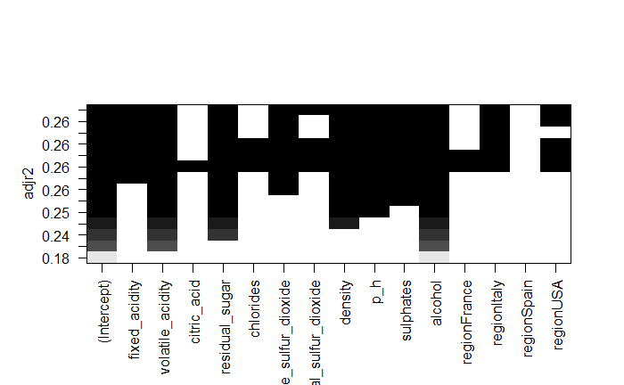

```r
plot(white_subsets, scale = "adjr2")
```

[figure not shown]

```r
plot(red_subsets_forward, scale = "bic")
```

## Automated plots for all wines

It would be interesting to see how the automated model responds to the data containing both red and white wines. I joined the datasets at the beginning, but as they had different profiles, I decided to build models separately.

```r
wines_regsubset <- regsubsets(quality ~ ., data =  wines_trim, nvmax = 15, method = "exhaustive")

wines_regsubset
```

```
Subset selection object
Call: regsubsets.formula(quality ~ ., data = wines_trim, nvmax = 15,
    method = "exhaustive")
16 Variables  (and intercept)
                     Forced in Forced out
fixed_acidity            FALSE      FALSE
volatile_acidity         FALSE      FALSE
citric_acid              FALSE      FALSE
residual_sugar           FALSE      FALSE
chlorides                FALSE      FALSE
free_sulfur_dioxide      FALSE      FALSE
total_sulfur_dioxide     FALSE      FALSE
density                  FALSE      FALSE
p_h                      FALSE      FALSE
sulphates                FALSE      FALSE
alcohol                  FALSE      FALSE
regionFrance             FALSE      FALSE
regionItaly              FALSE      FALSE
regionSpain              FALSE      FALSE
regionUSA                FALSE      FALSE
typeWhite                FALSE      FALSE
1 subsets of each size up to 15
Selection Algorithm: exhaustive
```

```r
sum_wines_regsubset <- summary(wines_regsubset)

sum_wines_regsubset
```

```
Subset selection object
Call: regsubsets.formula(quality ~ ., data = wines_trim, nvmax = 15,
    method = "exhaustive")
16 Variables  (and intercept)
                     Forced in Forced out
fixed_acidity            FALSE      FALSE
volatile_acidity         FALSE      FALSE
citric_acid              FALSE      FALSE
residual_sugar           FALSE      FALSE
chlorides                FALSE      FALSE
free_sulfur_dioxide      FALSE      FALSE
total_sulfur_dioxide     FALSE      FALSE
density                  FALSE      FALSE
p_h                      FALSE      FALSE
sulphates                FALSE      FALSE
alcohol                  FALSE      FALSE
regionFrance             FALSE      FALSE
regionItaly              FALSE      FALSE
regionSpain              FALSE      FALSE
regionUSA                FALSE      FALSE
typeWhite                FALSE      FALSE
1 subsets of each size up to 15
Selection Algorithm: exhaustive
          fixed_acidity volatile_acidity citric_acid residual_sugar chlorides free_sulfur_dioxide total_sulfur_dioxide density p_h
1  ( 1 )  " "           " "              " "         " "            " "       " "                 " "                  " "     " "
2  ( 1 )  " "           "*"              " "         " "            " "       " "                 " "                  " "     " "
3  ( 1 )  " "           "*"              " "         " "            " "       " "                 " "                  " "     " "
4  ( 1 )  " "           "*"              " "         "*"            " "       " "                 " "                  " "     " "
5  ( 1 )  " "           "*"              " "         "*"            " "       " "                 " "                  " "     " "
6  ( 1 )  " "           "*"              " "         "*"            " "       "*"                 "*"                  " "     " "
7  ( 1 )  " "           "*"              " "         "*"            " "       "*"                 "*"                  " "     "*"
8  ( 1 )  "*"           "*"              " "         "*"            " "       " "                 " "                  "*"     "*"
9  ( 1 )  "*"           "*"              " "         "*"            " "       "*"                 " "                  "*"     "*"
10  ( 1 ) "*"           "*"              " "         "*"            " "       "*"                 "*"                  "*"     "*"
11  ( 1 ) "*"           "*"              " "         "*"            "*"       "*"                 "*"                  "*"     "*"
12  ( 1 ) "*"           "*"              " "         "*"            "*"       "*"                 "*"                  "*"     "*"
13  ( 1 ) "*"           "*"              "*"         "*"            "*"       "*"                 "*"                  "*"     "*"
14  ( 1 ) "*"           "*"              "*"         "*"            "*"       "*"                 "*"                  "*"     "*"
15  ( 1 ) "*"           "*"              "*"         "*"            "*"       "*"                 "*"                  "*"     "*"
          sulphates alcohol regionFrance regionItaly regionSpain regionUSA typeWhite
1  ( 1 )  " "       "*"     " "          " "         " "         " "       " "
2  ( 1 )  " "       "*"     " "          " "         " "         " "       " "
3  ( 1 )  "*"       "*"     " "          " "         " "         " "       " "
4  ( 1 )  " "       "*"     " "          " "         " "         " "       "*"
5  ( 1 )  "*"       "*"     " "          " "         " "         " "       "*"
6  ( 1 )  "*"       "*"     " "          " "         " "         " "       " "
7  ( 1 )  "*"       "*"     " "          " "         " "         " "       " "
8  ( 1 )  "*"       "*"     " "          " "         " "         " "       "*"
9  ( 1 )  "*"       "*"     " "          " "         " "         " "       "*"
10  ( 1 ) "*"       "*"     " "          " "         " "         " "       "*"
11  ( 1 ) "*"       "*"     " "          " "         " "         " "       "*"
12  ( 1 ) "*"       "*"     " "          "*"         " "         " "       "*"
13  ( 1 ) "*"       "*"     " "          "*"         " "         " "       "*"
14  ( 1 ) "*"       "*"     " "          "*"         " "         "*"       "*"
15  ( 1 ) "*"       "*"     "*"          "*"         " "         "*"       "*"
```

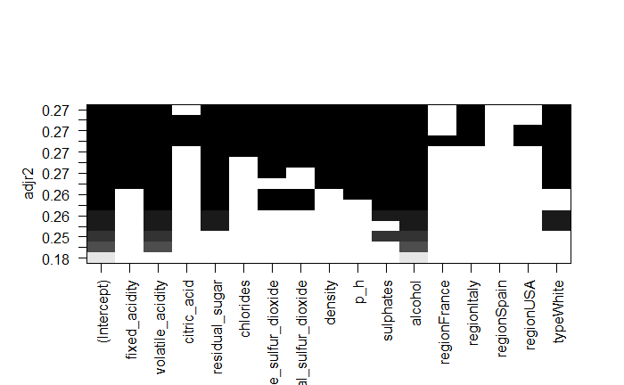

[output not shown]

```r
plot(wines_regsubset, scale = "adjr2")
```

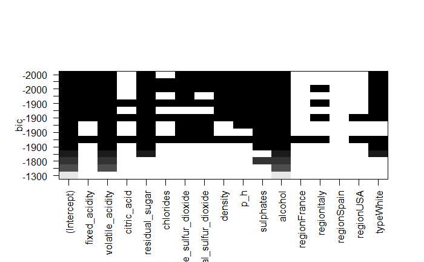

```r
plot(wines_regsubset, scale = "bic")
```

The adjusted R squared plot is not very helpful, as it shows that the best adjR2 contains most of the predictors (except citric acid, region France, USA and Spain)

The BIC plot is not much better, it shows the lowest bic score with all predictors, except those in the adjR2 and chlorides, region Italy

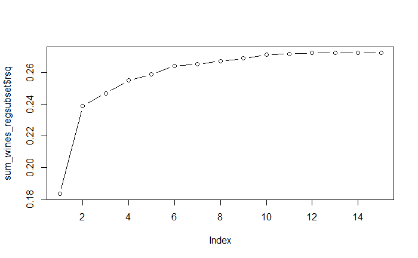

```r
plot(sum_wines_regsubset$rsq, type = "b")
```

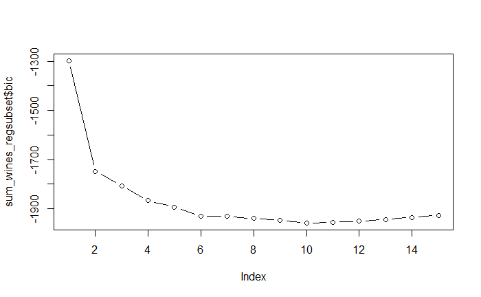

```r
plot(sum_wines_regsubset$bic, type = "b")
```

Summary:

- manual and automated models produced similar results, however some of the results from the automated need to be checked for significance
- there isn’t a clear pattern to the data, and overfitting may be a problem when adding too many predictors in order to improve the quality of the model.
- there isn’t a good correlation with quality for many of the variables, which may lead to fitting a model to noise.
- using the automated models and regsubset() it looks like the model will require at least 6 variable but I would be worried about overfitting, especially as some of these variables are not significant.